# Tugas Kuliah K3 (ARDL)

# 1. Library

```r
library(readxl)
library(dplyr)
```

```r
library(ggplot2)
library(tidyr)
library(corrplot)
library(forecast)
library(nardl)
library(dLagM)
library(ARDL)
library(dynamac)
library(car)
library(lmtest)
library(tseries)
library(moments)
library(patchwork)
library(openxlsx)
library(writexl)
```

# 2. Import Data

```r
dataset <- read_excel("Data_Harian_2022_2024.xlsx")

dataset$Date <- as.Date(dataset$Date)

str(dataset)
```

```
## tibble [1,096 × 6] (S3: tbl_df/tbl/data.frame)
##  $ Date: Date[1:1096], format: "2022-01-01" "2022-01-02" ...
##  $ TMA : num [1:1096] 595 588 580 576 574 ...
##  $ TM  : num [1:1096] 24.1 24.2 24.8 24.9 25.5 ...
##  $ PC  : num [1:1096] 0.85 1.79 0.4 0.22 5.7 ...
##  $ RH  : num [1:1096] 86.4 88.1 83.2 80.3 83.2 ...
##  $ WS  : num [1:1096] 2.08 2.25 1.56 1.11 0.79 1.38 1.92 1.35 1.82 1.41 ...
```

Data yang digunakan merupakan data harian yang terdiri atas:

- **TMA** = Tinggi Muka Air (cm), sebagai peubah respon.
- **PC** = Curah Hujan (mm/jam), sebagai peubah penjelas pertama.
- **RH** = Kelembapan Relatif (%), sebagai peubah penjelas kedua.

Dalam analisis ini hanya digunakan PC dan RH sebagai peubah penjelas karena keduanya memiliki hubungan linear yang lebih kuat dengan TMA dibandingkan TM dan WS.

# 3. **Eksplorasi Data**

## 3.1 **Statistika Deskriptif Dasar**

### **3.1.1 Statistika Deskriptif Dasar**

```r
summary(dataset)
```

```
##       Date                 TMA              TM              PC
##  Min.   :2022-01-01   Min.   :555.4   Min.   :22.85   Min.   :  0.0000
##  1st Qu.:2022-10-01   1st Qu.:597.7   1st Qu.:24.57   1st Qu.:  0.7375
##  Median :2023-07-02   Median :620.0   Median :25.10   Median :  4.0000
##  Mean   :2023-07-02   Mean   :625.3   Mean   :25.18   Mean   :  6.5700
##  3rd Qu.:2024-04-01   3rd Qu.:650.1   3rd Qu.:25.78   3rd Qu.:  9.1325
##  Max.   :2024-12-31   Max.   :781.2   Max.   :27.97   Max.   :145.0300
##        RH              WS
##  Min.   :67.03   Min.   :0.460
##  1st Qu.:82.92   1st Qu.:1.010
##  Median :86.29   Median :1.230
##  Mean   :85.29   Mean   :1.377
##  3rd Qu.:88.53   3rd Qu.:1.583
##  Max.   :94.31   Max.   :3.700
```

### 3.1.2 Standard Deviation

```r
sd_tma <- sd(dataset$TMA, na.rm = TRUE)
sd_pc <- sd(dataset$PC, na.rm = TRUE)
sd_rh <- sd(dataset$RH, na.rm = TRUE)

cat("Standard deviation TMA:", sd_tma, "\n")
```

```
## Standard deviation TMA: 39.44962
```

```r
cat("Standard deviation PC:", sd_pc, "\n")
```

```
## Standard deviation PC: 8.838259
```

```r
cat("Standard deviation RH:", sd_rh, "\n")
```

```
## Standard deviation RH: 4.710888
```

> Nilai standar deviasi TMA sebesar **39.45**, PC sebesar **8.84**, dan RH sebesar **4.71**. Hal ini menunjukkan bahwa TMA memiliki penyebaran data paling besar dibandingkan PC dan RH.

### 3.1.3 Skewness

```r
skew_tma <- skewness(dataset$TMA, na.rm = TRUE)
skew_pc <- skewness(dataset$PC, na.rm = TRUE)
skew_rh <- skewness(dataset$RH, na.rm = TRUE)

cat("Skewness TMA:", skew_tma, "\n")
```

```
## Skewness TMA: 0.5304754
```

```r
cat("Skewness PC:", skew_pc, "\n")
```

```
## Skewness PC: 5.070871
```

```r
cat("Skewness RH:", skew_rh, "\n")
```

```
## Skewness RH: -0.9881591
```

> Nilai skewness TMA sebesar **0.53** menunjukkan distribusi sedikit menjulur ke kanan. PC memiliki skewness sebesar **5.07** yang menunjukkan kemenjuluran ke kanan yang sangat kuat. Sementara itu, RH memiliki skewness sebesar **-0.99** yang menunjukkan sebaran menjulur ke kiri.

### 3.1.4 Kurtosis

```r
kurt_tma <- kurtosis(dataset$TMA, na.rm = TRUE)
kurt_pc <- kurtosis(dataset$PC, na.rm = TRUE)
kurt_rh <- kurtosis(dataset$RH, na.rm = TRUE)

cat("Kurtosis TMA:", kurt_tma, "\n")
```

```
## Kurtosis TMA: 2.984404
```

```r
cat("Kurtosis PC:", kurt_pc, "\n")
```

```
## Kurtosis PC: 62.19679
```

```r
cat("Kurtosis RH:", kurt_rh, "\n")
```

```
## Kurtosis RH: 4.025032
```

> Nilai kurtosis TMA sebesar **2.98** menunjukkan sebaran yang mendekati distribusi normal. PC memiliki kurtosis sebesar **62.20**, yang menunjukkan adanya ekor sebaran yang sangat berat dan kemungkinan terdapat nilai ekstrem. RH memiliki kurtosis sebesar **4.03**, yang menunjukkan sebaran dengan ekor yang lebih berat dibandingkan sebaran normal.

## 3.2 **Time Series**

### 3.2.1 Plot Time Series TMA

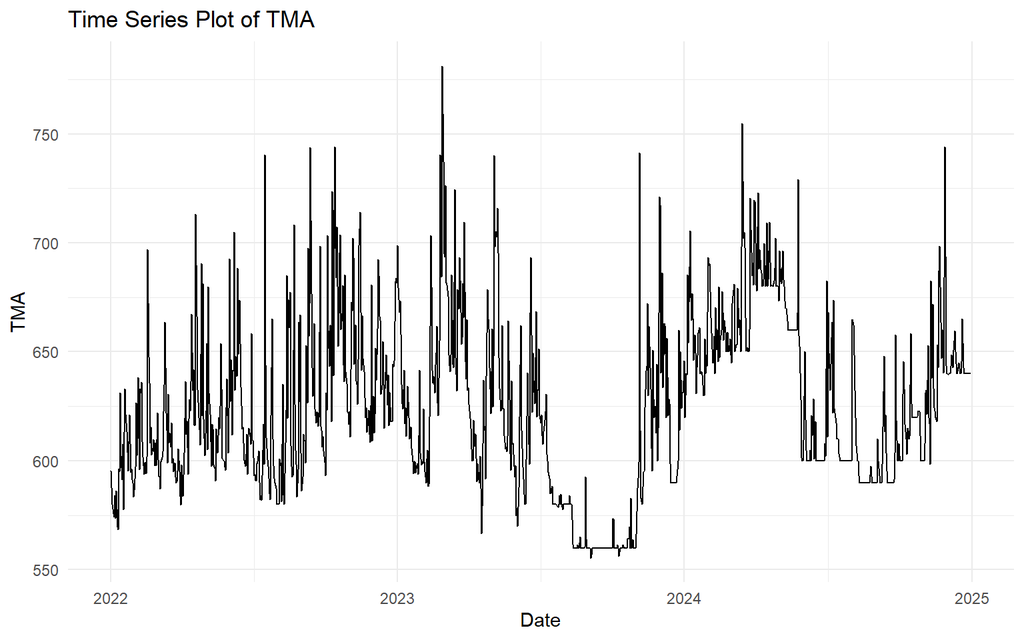

```r
ggplot(data = dataset, aes(x = Date, y = TMA)) +
  geom_line() +
  labs(title = "Time Series Plot of TMA", x = "Date", y = "TMA") +
  theme_minimal()
```

### 3.2.2 Plot Time Series PC

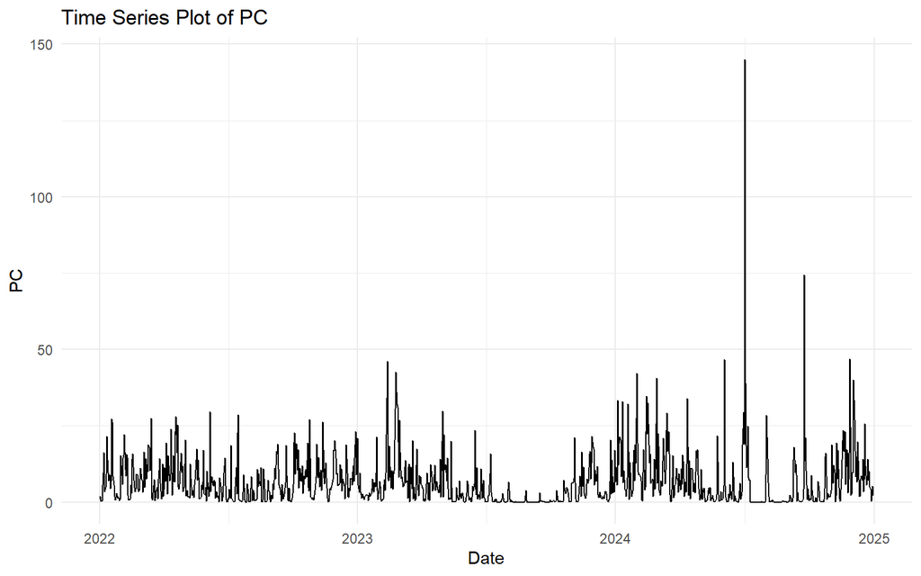

```r
ggplot(data = dataset, aes(x = Date, y = PC)) +
  geom_line() +
  labs(title = "Time Series Plot of PC", x = "Date", y = "PC") +
  theme_minimal()
```

### 3.2.3 Plot Time Series RH

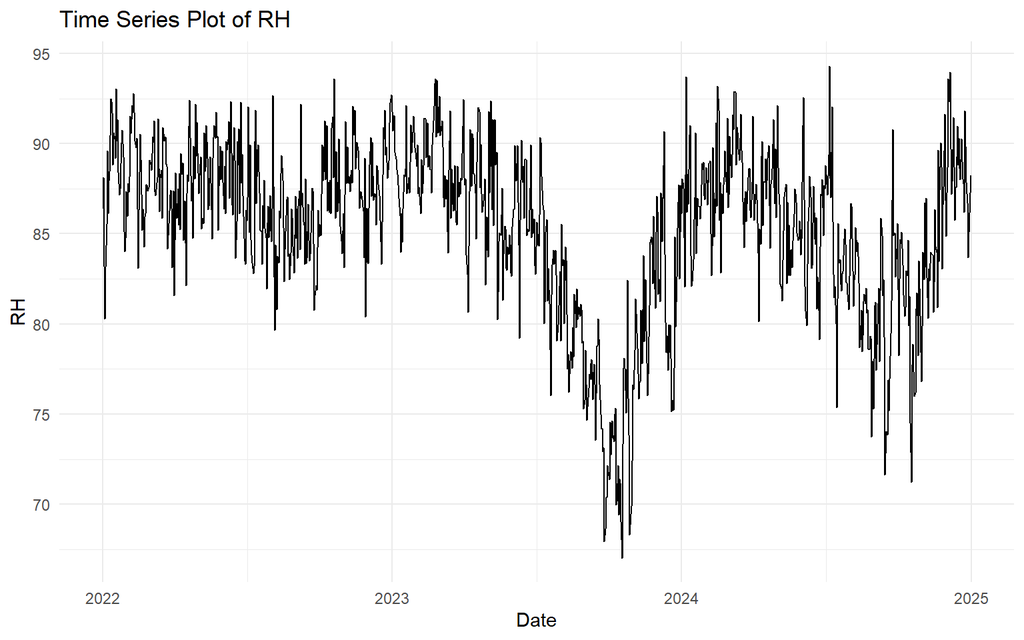

```r
ggplot(data = dataset, aes(x = Date, y = RH)) +
  geom_line() +
  labs(title = "Time Series Plot of RH", x = "Date", y = "RH") +
  theme_minimal()
```

### 3.2.4 Plot Time Series Gabungan

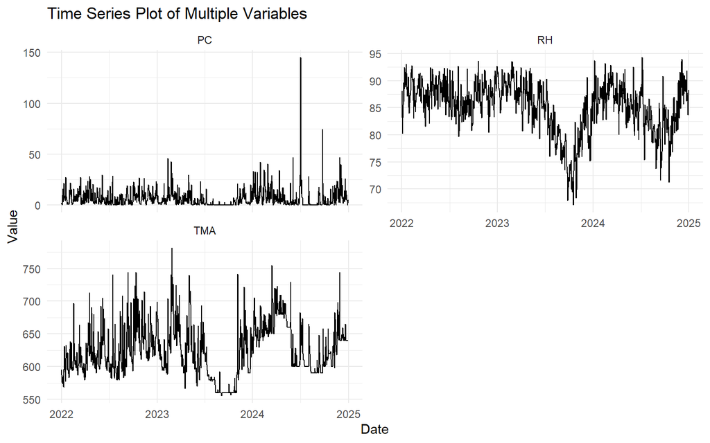

```r
# Ubah data menjadi long format
data_long <- dataset %>%
  pivot_longer(cols = c(TMA, PC, RH),
               names_to = "Variabel",
               values_to = "Nilai")

# Membuat plot dengan facet_wrap
ggplot(data_long, aes(x = Date, y = Nilai)) +
  geom_line() +
  facet_wrap(~ Variabel, scales = "free_y", ncol = 2) +
  labs(title = "Time Series Plot of Multiple Variables",
       x = "Date",
       y = "Value") +
  theme_minimal()
```

Secara keseluruhan, ketiga variabel menunjukkan **fluktuasi yang cukup besar sepanjang periode pengamatan**. PC memiliki beberapa lonjakan ekstrem, RH mengalami perubahan level pada beberapa periode, sedangkan TMA menunjukkan perubahan naik-turun yang cukup tajam. Dari plot ini belum terlihat pola musiman yang konsisten, sehingga diperlukan analisis lebih lanjut mengenai **kestasioneran data** sebelum dilakukan pemodelan ARDL.

## 3.3 Matriks Korelasi

```r
cor_matrix <- cor(dataset[, c("TMA", "PC", "RH")], use = "complete.obs")
cor_matrix
```

```
##           TMA        PC        RH
## TMA 1.0000000 0.3945932 0.5250838
## PC  0.3945932 1.0000000 0.4196228
## RH  0.5250838 0.4196228 1.0000000
```

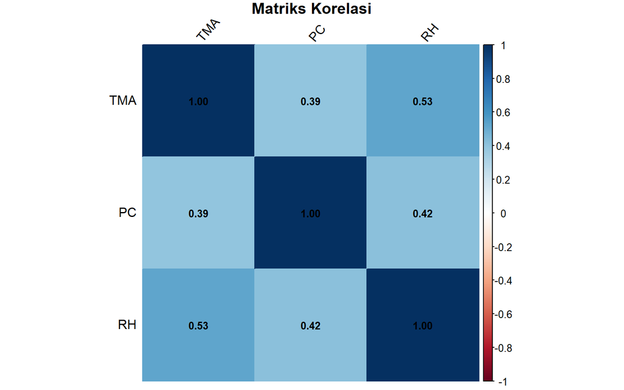

```r
corrplot(cor_matrix, method = "color", addCoef.col = "black",
         tl.col = "black", tl.srt = 50, number.cex = 0.8,
         title = "Matriks Korelasi",
         mar = c(0,0,1,0))
```

PC memiliki korelasi positif dengan TMA sebesar **0.39**, sedangkan RH memiliki korelasi positif sebesar **0.53**. Artinya, RH memiliki hubungan linear yang lebih kuat dengan TMA dibandingkan PC.

# 4. Data Splitting

```r
total_rows <- 1096
test_size <- 160

train_index <- 1:(total_rows - test_size)
test_index  <- (total_rows - test_size + 1):total_rows

train_2225 <- dataset[train_index, ]
test_2225  <- dataset[test_index, ]
str(train_2225)
```

```
## tibble [936 × 6] (S3: tbl_df/tbl/data.frame)
##  $ Date: Date[1:936], format: "2022-01-01" "2022-01-02" ...
##  $ TMA : num [1:936] 595 588 580 576 574 ...
##  $ TM  : num [1:936] 24.1 24.2 24.8 24.9 25.5 ...
##  $ PC  : num [1:936] 0.85 1.79 0.4 0.22 5.7 ...
##  $ RH  : num [1:936] 86.4 88.1 83.2 80.3 83.2 ...
##  $ WS  : num [1:936] 2.08 2.25 1.56 1.11 0.79 1.38 1.92 1.35 1.82 1.41 ...
```

```r
str(test_2225)
```

```
## tibble [160 × 6] (S3: tbl_df/tbl/data.frame)
##  $ Date: Date[1:160], format: "2024-07-25" "2024-07-26" ...
##  $ TMA : num [1:160] 600 600 600 600 600 ...
##  $ TM  : num [1:160] 24.4 24.9 24.9 24.7 24.5 ...
##  $ PC  : num [1:160] 0.01 0.01 0 0 0 ...
##  $ RH  : num [1:160] 85.3 84.4 82.3 82.3 81.6 ...
##  $ WS  : num [1:160] 1.32 1.13 1.24 1.01 1.16 1.35 1.25 1.01 0.98 0.99 ...
```

```r
train_2225.ts<-ts(train_2225)
test_2225.ts<-ts(test_2225)
```

## 4.1 **Time Series Data Split**

```r
train_2225 <- train_2225 %>%
  mutate(DataType = "Train")

test_2225 <- test_2225 %>%
  mutate(DataType = "Test")
```

### 4.1.1 Plot Time Series TMA

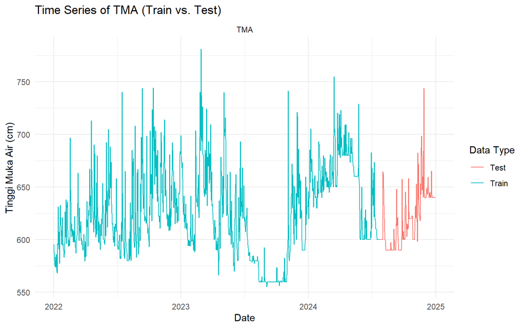

```r
combined_data <- bind_rows(train_2225, test_2225)
data_long <- combined_data %>%
  pivot_longer(cols = c(TMA),
               names_to = "Variabel",
               values_to = "Nilai")

ggplot(data_long, aes(x = Date, y = Nilai, color = DataType)) +
  geom_line() +
  facet_wrap(~ Variabel, scales = "free_y", ncol = 2) +
  scale_color_manual(values = c("Train" = "#00BFC4", "Test" = "#F8766D")) +
  labs(title = "Time Series of TMA (Train vs. Test)",
       x = "Date",
       y = "Tinggi Muka Air (cm)",
       color = "Data Type") +
  theme_minimal()
```

### 4.1.2 Plot Time Series PC

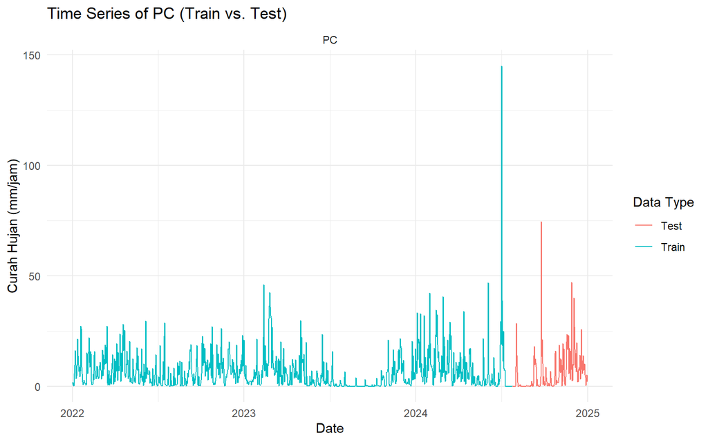

```r
combined_data <- bind_rows(train_2225, test_2225)
data_long <- combined_data %>%
  pivot_longer(cols = c(PC),
               names_to = "Variabel",
               values_to = "Nilai")

ggplot(data_long, aes(x = Date, y = Nilai, color = DataType)) +
  geom_line() +
  facet_wrap(~ Variabel, scales = "free_y", ncol = 2) +
  scale_color_manual(values = c("Train" = "#00BFC4", "Test" = "#F8766D")) +
  labs(title = "Time Series of PC (Train vs. Test)",
       x = "Date",
       y = "Curah Hujan (mm/jam)",
       color = "Data Type") +
  theme_minimal()
```

### 4.1.3 Plot Time Series RH

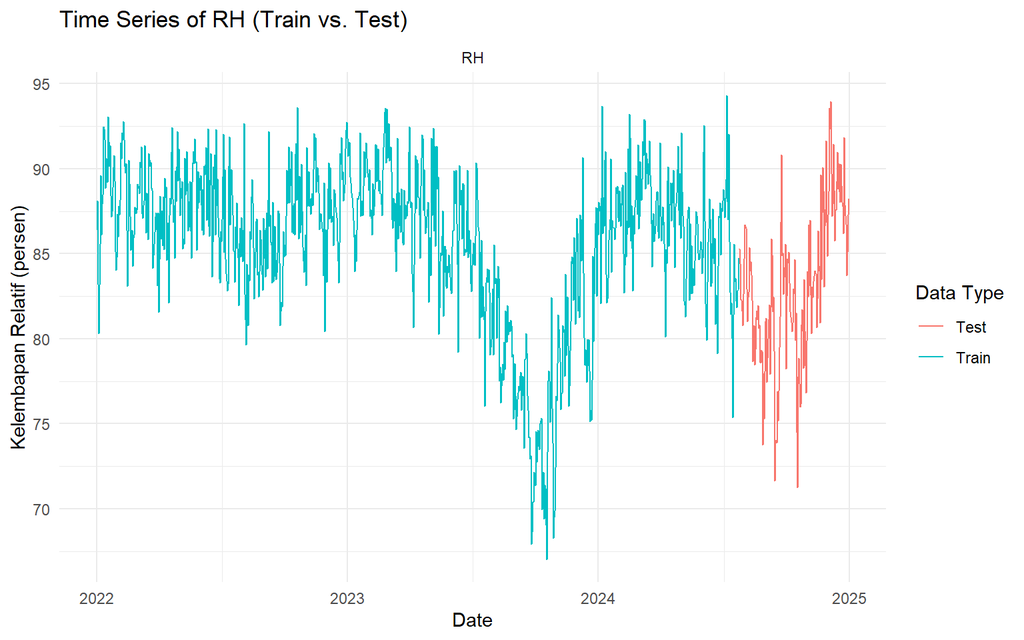

```r
combined_data <- bind_rows(train_2225, test_2225)
data_long <- combined_data %>%
  pivot_longer(cols = c(RH),
               names_to = "Variabel",
               values_to = "Nilai")

ggplot(data_long, aes(x = Date, y = Nilai, color = DataType)) +
  geom_line() +
  facet_wrap(~ Variabel, scales = "free_y", ncol = 2) +
  scale_color_manual(values = c("Train" = "#00BFC4", "Test" = "#F8766D")) +
  labs(title = "Time Series of RH (Train vs. Test)",
       x = "Date",
       y = "Kelembapan Relatif (persen)",
       color = "Data Type") +
  theme_minimal()
```

### 4.1.4 Plot Time Series Gabungan

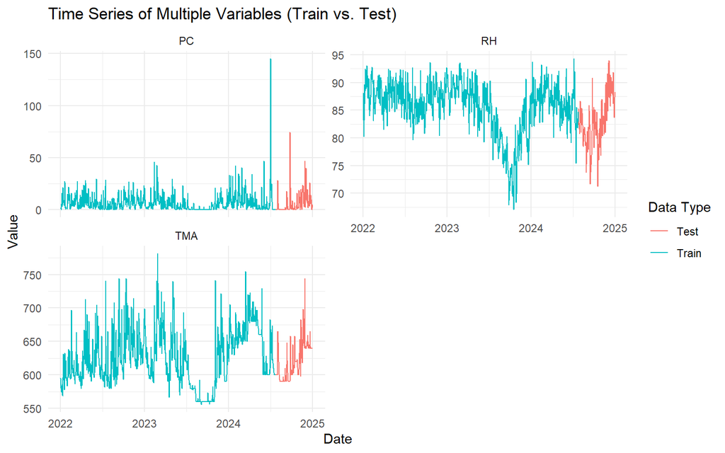

```r
combined_data <- bind_rows(train_2225, test_2225)
data_long <- combined_data %>%
  pivot_longer(cols = c(TMA, PC, RH),
               names_to = "Variabel",
               values_to = "Nilai")

ggplot(data_long, aes(x = Date, y = Nilai, color = DataType)) +
  geom_line() +
  facet_wrap(~ Variabel, scales = "free_y", ncol = 2) +
  scale_color_manual(values = c("Train" = "#00BFC4", "Test" = "#F8766D")) +
  labs(title = "Time Series of Multiple Variables (Train vs. Test)",
       x = "Date",
       y = "Value",
       color = "Data Type") +
  theme_minimal()
```

- **PC:** Data train dan test menunjukkan pola yang relatif serupa, meskipun terdapat beberapa lonjakan ekstrem pada data train.
- **RH:** Data train dan test sama-sama berfluktuasi, dengan rentang nilai yang relatif serupa.
- **TMA:** Data train dan test memiliki pola fluktuasi yang cukup serupa, meskipun terdapat beberapa perubahan nilai yang cukup tajam.

# 5. **Kestasioneran Data**

## 5.1 Plot ACF

### 5.1.1 Plot ACF TMA

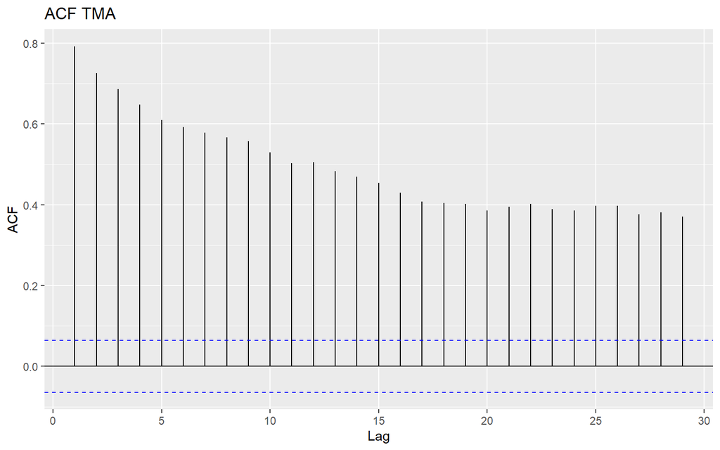

```r
acf_TMA <- ggAcf(train_2225$TMA) + labs(title = "ACF TMA")
acf_TMA
```

- Plot ACF TMA menurun secara perlahan: TMA tidak stasioner

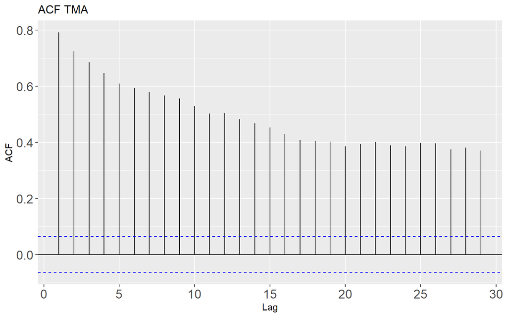

```r
acf_TMA <- ggAcf(train_2225$TMA) +
  labs(title = "ACF TMA") +
  theme(
    axis.text.x = element_text(size = 14),
    axis.text.y = element_text(size = 14)
  )
acf_TMA
```

### 5.1.2 Plot ACF PC

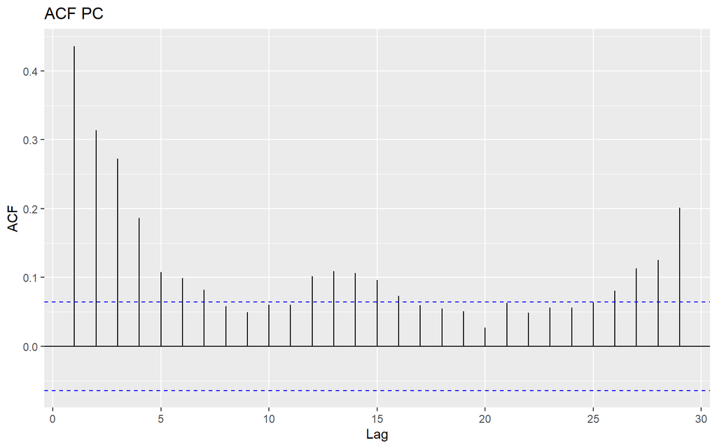

```r
acf_PC <- ggAcf(train_2225$PC) + labs(title = "ACF PC")
acf_PC
```

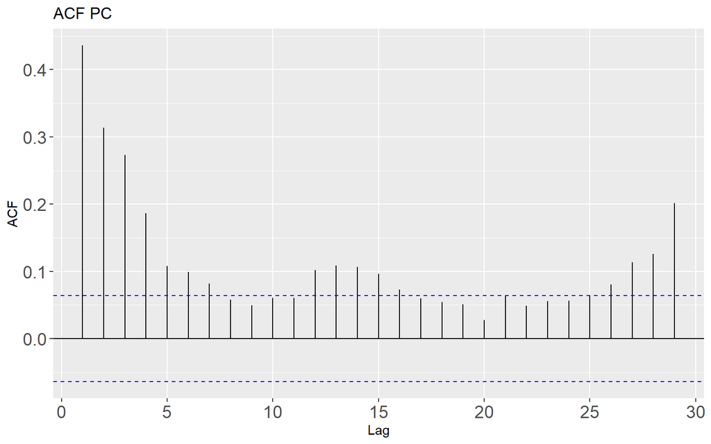

```r
acf_PC <- ggAcf(train_2225$PC) +
  labs(title = "ACF PC") +
  theme(
    axis.text.x = element_text(size = 14),
    axis.text.y = element_text(size = 14)
  )
acf_PC
```

### 5.1.3 Plot ACF RH

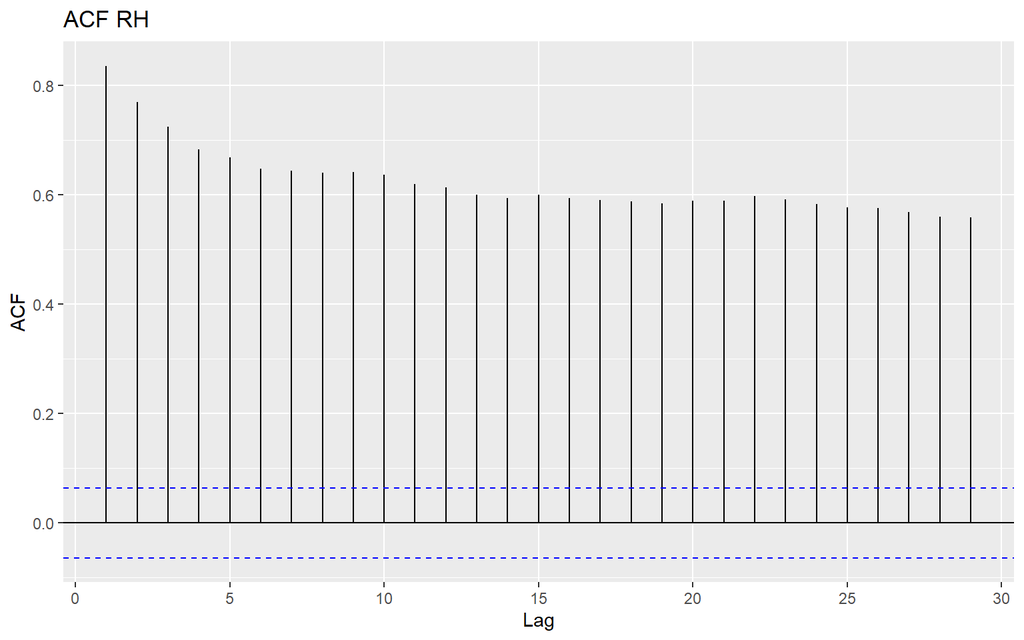

```r
acf_RH <- ggAcf(train_2225$RH) + labs(title = "ACF RH")
acf_RH
```

- Plot ACF RH menurun secara perlahan: RH tidak stasioner

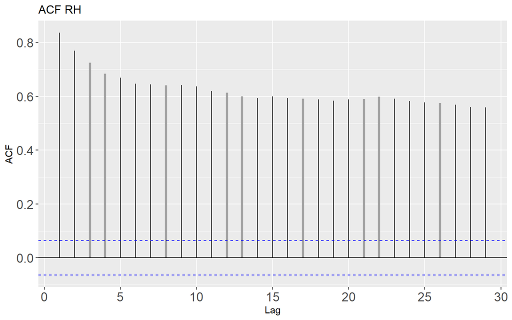

```r
acf_RH <- ggAcf(train_2225$RH) +
  labs(title = "ACF RH") +
  theme(
    axis.text.x = element_text(size = 14),
    axis.text.y = element_text(size = 14)
  )
acf_RH
```

### 5.1.4 Plot ACF Gabungan

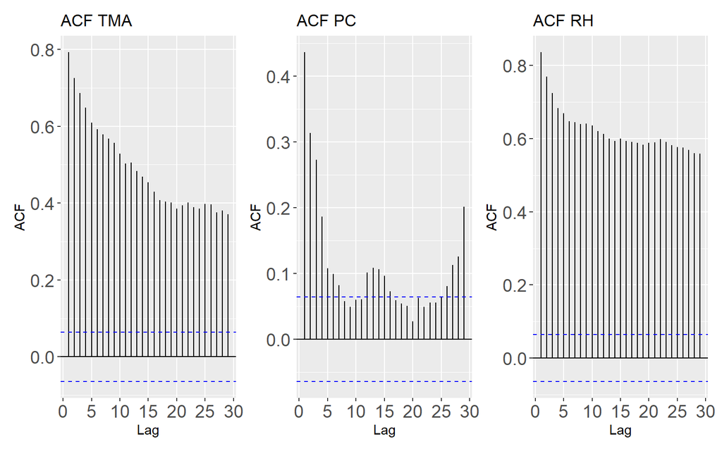

```r
combined_acf <- acf_TMA + acf_PC + acf_RH
combined_acf
```

## 5.2 Plot PACF

### 5.2.1 Plot PACF TMA

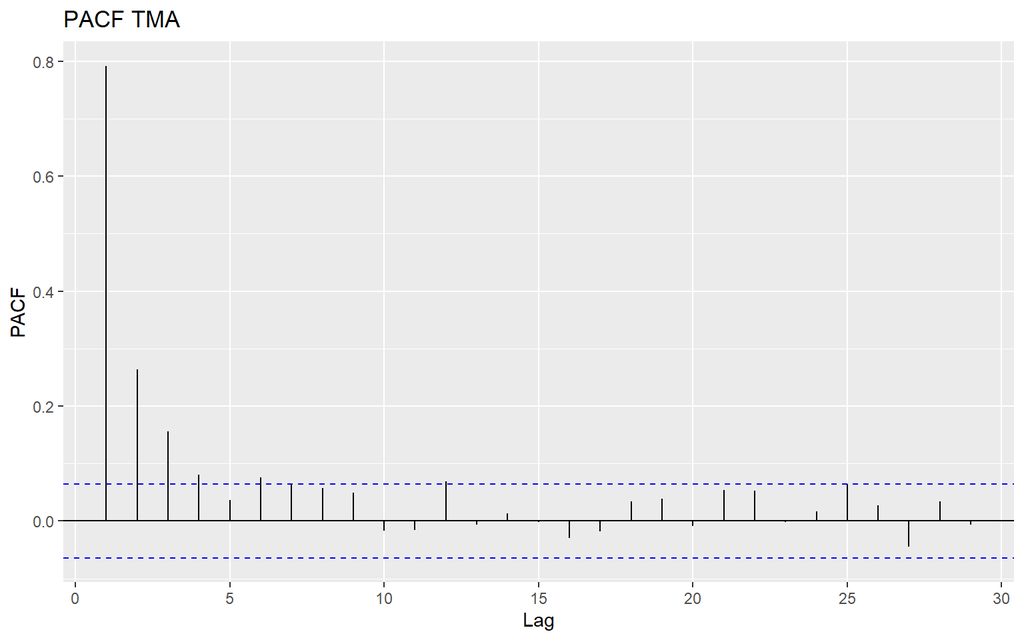

```r
pacf_TMA <- ggPacf(train_2225$TMA) + labs(title = "PACF TMA")
pacf_TMA
```

- Lag p antara 1 sampai 3, karena PACF memotong cut-off setelah lag-3

### 5.2.2 Plot PACF PC

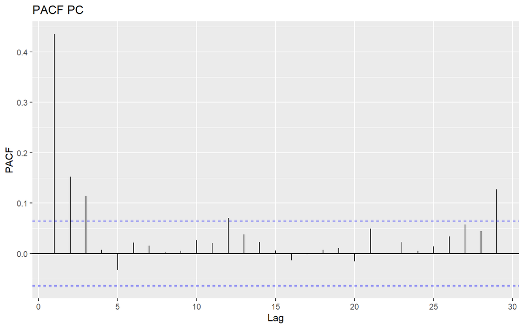

```r
pacf_PC <- ggPacf(train_2225$PC) + labs(title = "PACF PC")
pacf_PC
```

### 5.2.2 Plot PACF RH

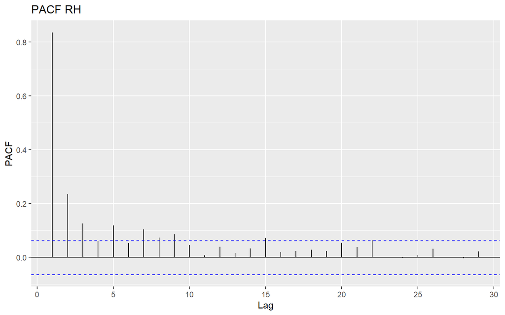

```r
pacf_RH <- ggPacf(train_2225$RH) + labs(title = "PACF RH")
pacf_RH
```

### 5.2.4 Plot PACF Gabungan

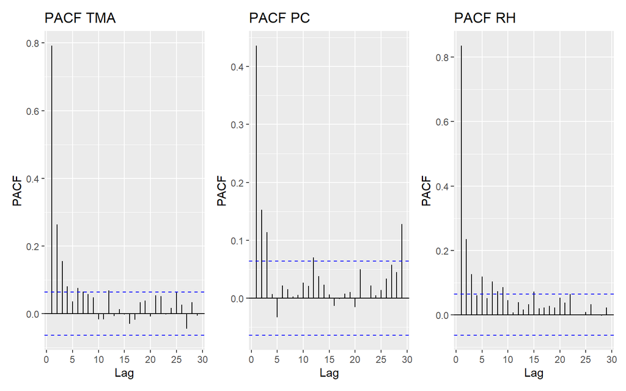

```r
combined_pacf <- pacf_TMA + pacf_PC + pacf_RH
combined_pacf
```

- **TMA:** PACF menunjukkan korelasi parsial paling kuat pada **lag 1**, kemudian menurun pada lag berikutnya.
- **PC:** Korelasi parsial paling kuat pada **lag 1**, dengan beberapa lag berikutnya masih menunjukkan nilai yang relatif kecil.
- **RH:** PACF paling kuat pada **lag 1**, kemudian cenderung menurun pada lag berikutnya.

Ketiga peubah menunjukkan adanya **ketergantungan terhadap nilai masa lalu**, terutama pada lag awal.

## 5.3 Uji ADF

### 5.3.1 Uji ADF TMA

```r
adf.test(train_2225$TMA)
```

```
##
##  Augmented Dickey-Fuller Test
##
## data:  train_2225$TMA
## Dickey-Fuller = -4.0015, Lag order = 9, p-value = 0.01
## alternative hypothesis: stationary
```

- TMA stasioner secara uji formal

### 5.3.2 Uji ADF PC

```r
adf.test(train_2225$PC)
```

```
##
##  Augmented Dickey-Fuller Test
##
## data:  train_2225$PC
## Dickey-Fuller = -7.5589, Lag order = 9, p-value = 0.01
## alternative hypothesis: stationary
```

- PC stasioner secara uji formal

### 5.3.3 Uji ADF RH

```r
adf.test(train_2225$RH)
```

```
##
##  Augmented Dickey-Fuller Test
##
## data:  train_2225$RH
## Dickey-Fuller = -3.3561, Lag order = 9, p-value = 0.06101
## alternative hypothesis: stationary
```

- RH tidak stasioner secara uji formal

# 6. **First Difference**

## 6.1 Differencing

```r
DTMA <- diff(train_2225$TMA, differences = 1)
DPC <- diff(train_2225$PC, differences = 1)
DRH <- diff(train_2225$RH, differences = 1)

# Gabungkan dalam dataframe
df <- data.frame(DTMA, DPC, DRH)
df.ts<-ts(df)
head(df)
```

```
##         DTMA   DPC   DRH
## 1  -7.708333  0.94  1.75
## 2  -7.500000 -1.39 -4.93
## 3  -4.375000 -0.18 -2.91
## 4  -1.458333  5.48  2.87
## 5   9.583333  3.75  2.39
## 6 -10.208333  6.72  4.06
```

## 6.2 Plot ACF

### 6.2.1 Plot ACF DTMA

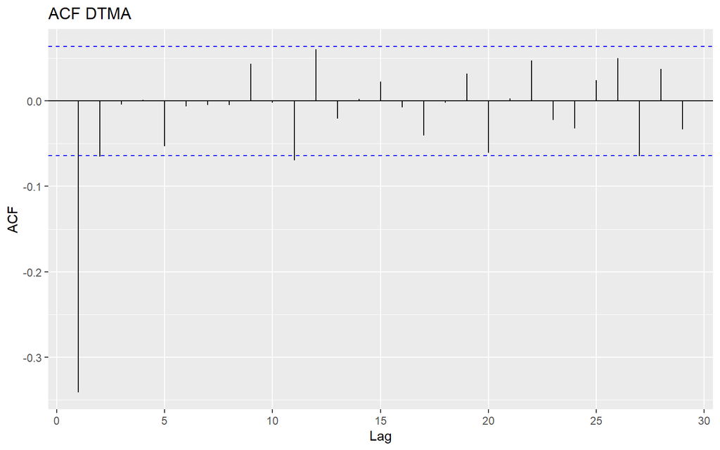

```r
acf_DTMA <- ggAcf(DTMA) + labs(title = "ACF DTMA")
acf_DTMA
```

- Plot ACF DTMA tidak menurun secara perlahan: TMA stasioner

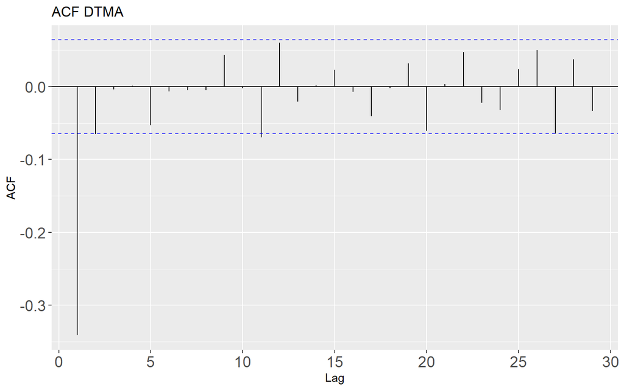

```r
acf_DTMA <- ggAcf(DTMA) +
  labs(title = "ACF DTMA") +
  theme(
    axis.text.x = element_text(size = 14),
    axis.text.y = element_text(size = 14)
  )
acf_DTMA
```

### 6.2.2 Plot ACF DPC

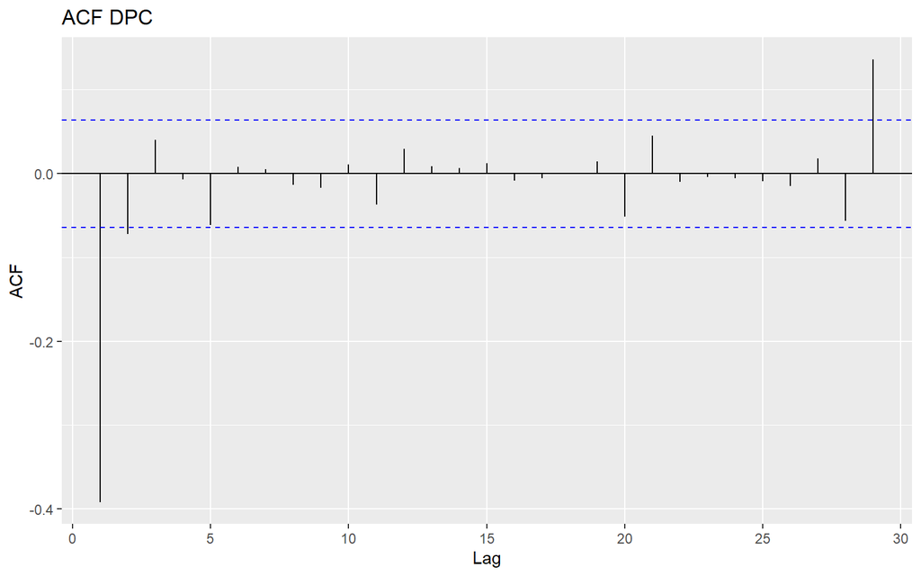

```r
acf_DPC <- ggAcf(DPC) + labs(title = "ACF DPC")
acf_DPC
```

- Plot ACF DPC tidak menurun secara perlahan : PC stasioner

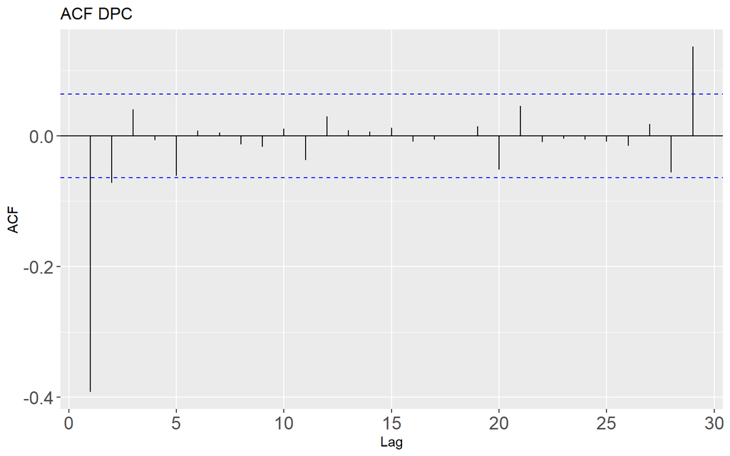

```r
acf_DPC <- ggAcf(DPC) +
  labs(title = "ACF DPC") +
  theme(
    axis.text.x = element_text(size = 14),
    axis.text.y = element_text(size = 14)
  )
acf_DPC
```

### 6.2.3 Plot ACF DRH

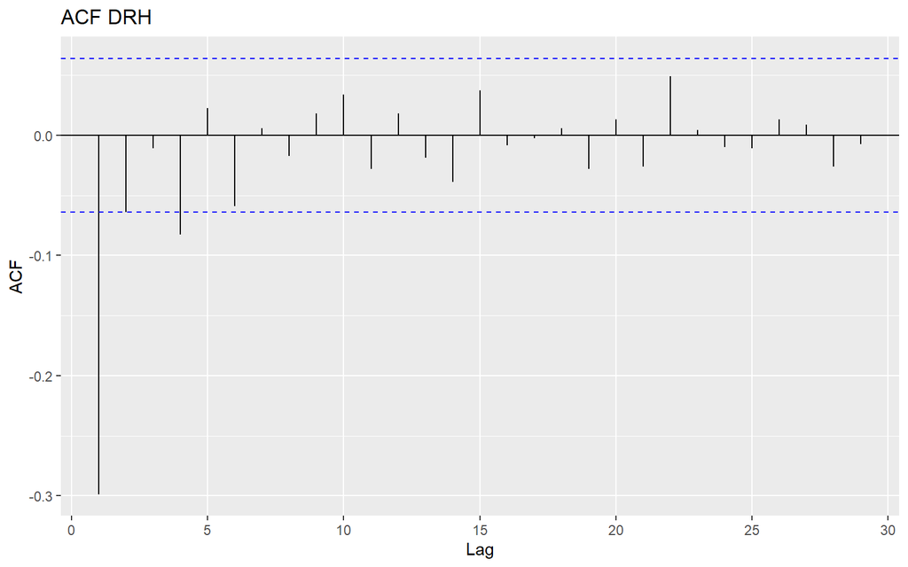

```r
acf_DRH <- ggAcf(DRH) + labs(title = "ACF DRH")
acf_DRH
```

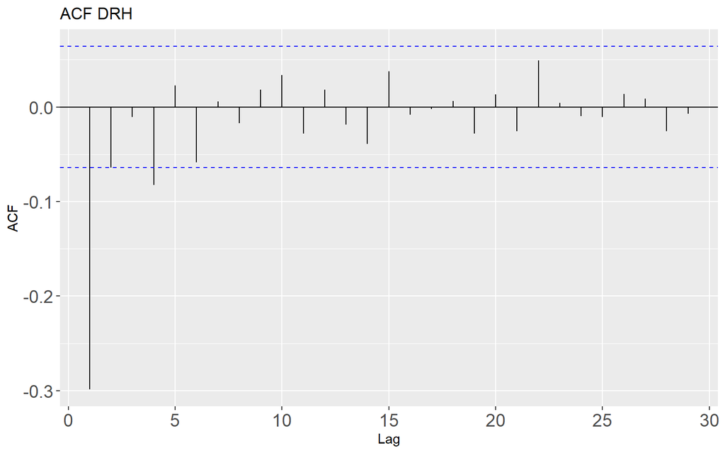

```r
acf_DRH <- ggAcf(DRH) +
  labs(title = "ACF DRH") +
  theme(
    axis.text.x = element_text(size = 14),
    axis.text.y = element_text(size = 14)
  )
acf_DRH
```

### 6.2.4 Plot ACF Gabungan

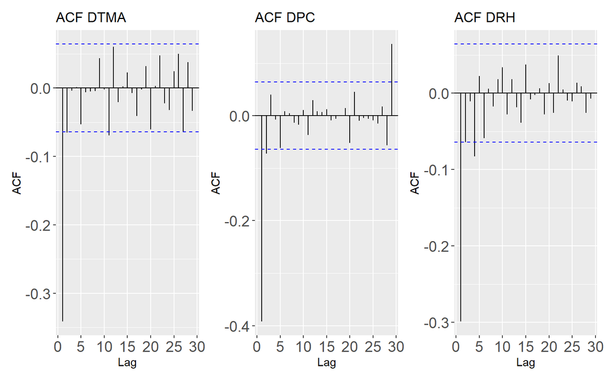

```r
combined_acf <- acf_DTMA + acf_DPC + acf_DRH
combined_acf
```

- **DTMA:** ACF menunjukkan korelasi negatif kuat pada **lag 1**, kemudian sebagian besar lag berada dalam batas signifikansi.
- **DPC:** ACF didominasi korelasi negatif pada **lag 1**, sementara lag berikutnya relatif kecil.
- **DRH:** ACF menunjukkan korelasi negatif kuat pada **lag 1**, kemudian menurun pada lag berikutnya.

Setelah dilakukan *first difference*, korelasi antarperiode menjadi lebih kecil dan data cenderung lebih stasioner.

## 6.3 **Plot PACF**

### 6.3.1 Plot PACF DTMA (Lag optimum peubah respon)

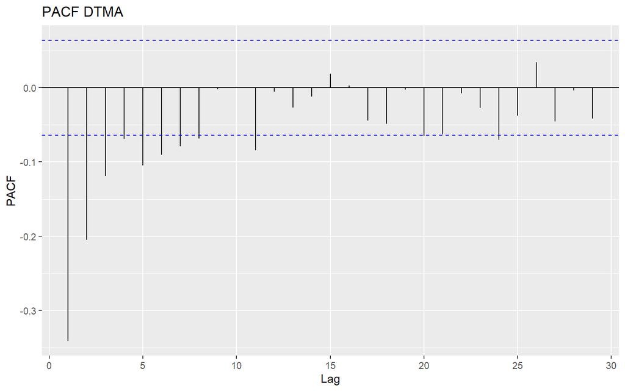

```r
pacf_DTMA <- ggPacf(DTMA) + labs(title = "PACF DTMA")
pacf_DTMA
```

- Lag p antara 1 sampai 8, karena PACF memotong cut-off setelah lag-8

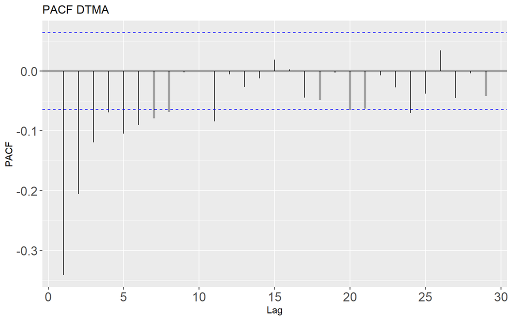

```r
pacf_DTMA <- ggPacf(DTMA) +
  labs(title = "PACF DTMA") +
  theme(
    axis.text.x = element_text(size = 14),
    axis.text.y = element_text(size = 14)
  )
pacf_DTMA
```

### 6.3.2 Plot PACF DPC

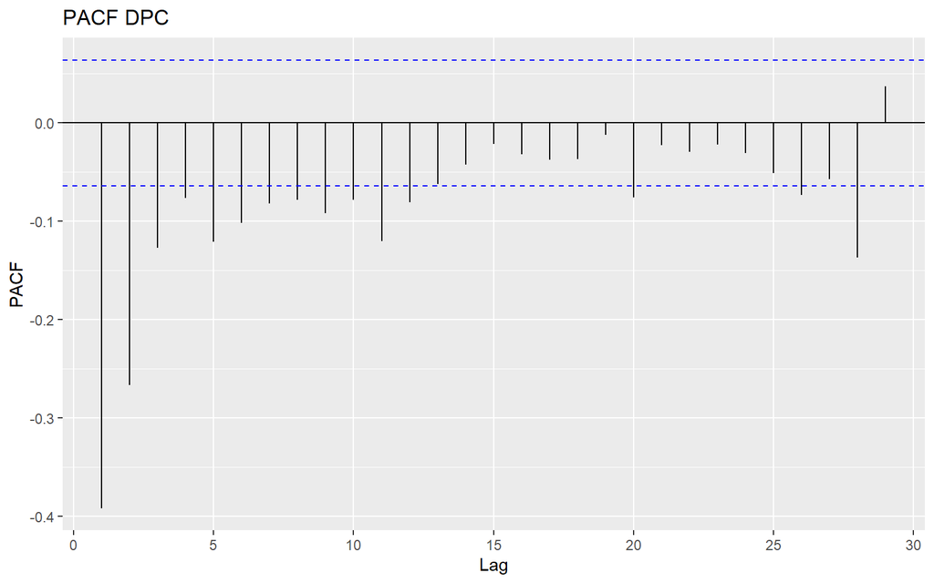

```r
pacf_DPC <- ggPacf(DPC) + labs(title = "PACF DPC")
pacf_DPC
```

### 6.3.3 Plot PACF DRH

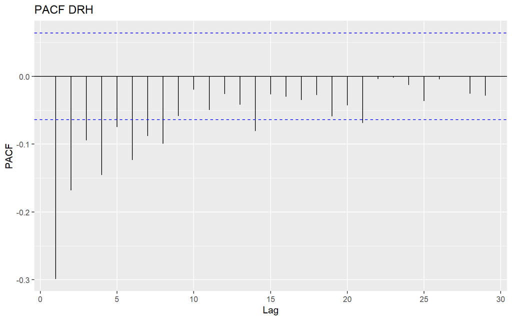

```r
pacf_DRH <- ggPacf(DRH) + labs(title = "PACF DRH")
pacf_DRH
```

### 6.3.4 Plot PACF Gabungan

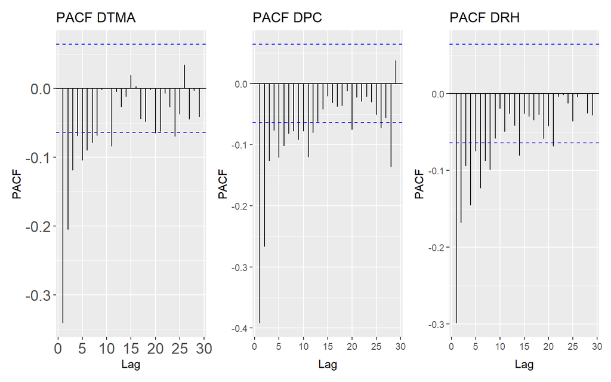

```r
combined_pacf <- pacf_DTMA + pacf_DPC + pacf_DRH
combined_pacf
```

- **DTMA:** Korelasi parsial paling kuat pada **lag 1**, kemudian cenderung menurun.
- **DPC:** Korelasi parsial paling kuat pada **lag 1**, dengan beberapa lag berikutnya masih signifikan.
- **DRH:** Korelasi parsial paling kuat pada **lag 1**, kemudian menurun pada lag berikutnya.

Ketiga peubah memiliki ketergantungan terhadap nilai masa lalu, terutama pada **lag 1**, setelah dilakukan *first difference*.